# 3 Exploratory and Descriptive Analyses

## 3.1 Explaining EDA goals & key findings

The goal of this EDA is to understand how students perform across the three grade assessments (G1, G2, G3) and which factors appear most related to the final grade (G3). First, I summarize grade distributions to see typical performance levels and variation. Then I examine how study time, absences, and school relate to G3, followed by a simple correlation overview of key numeric predictors.

Overall, final grades tend to cluster in the mid-range, with relatively few students at the very low or very high end. Study time shows a generally positive association with G3, while higher numbers of absences are linked with lower final grades. Differences in mean G3 by school are present but not dramatic. Correlation patterns confirm that G1 and G2 are strongly tied to G3, while variables such as absences, failures, and alcohol consumption have weaker linear relationships.

### 3.1.1 Grade summaries

```r
grade_summary <- summarize_grades(analysis_data)
if(!is.null(grade_summary)){
  gt(grade_summary) |>
    fmt_number(c(mean, sd), decimals = 2)
}
```

| grade | n | mean | sd | min | q1 | median | q3 | max |
| --- | --- | --- | --- | --- | --- | --- | --- | --- |
| G1 | 395 | 10.91 | 3.32 | 3 | 8 | 11 | 13 | 19 |
| G2 | 395 | 10.71 | 3.76 | 0 | 9 | 11 | 13 | 19 |
| G3 | 395 | 10.42 | 4.58 | 0 | 8 | 11 | 14 | 20 |

**Comment:** G1 and G2 have similar averages and distributions to G3, indicating that earlier grades closely reflect final grade performance.

**Modeling implication:** Include G1 and G2 as strong predictors, but check for multicollinearity before including both in the model.

### 3.1.2 Study time vs. final grade

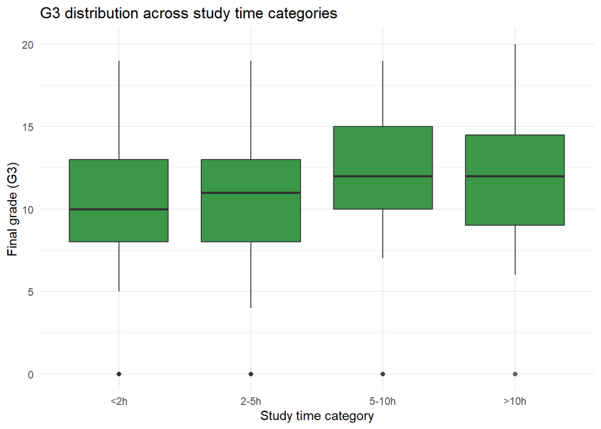

```r
plot_studytime_vs_grade(analysis_data)
```

**Comment:** Students who study **5–10 hours per week** generally achieve **higher final grades**, while very low study time tends to associate with lower performance. However, when study timeexceeds 10 hours, the average final grade appears to **drop slightly** **Modeling implication:** Study time is a useful predictor for G3 and could be treated as an **ordinal categorical variable**. Consider checking linearity before using it directly in regression or applying dummy encoding.

### 3.1.3 Final grade by school

```r
# EXPECTED: a tibble with mean/sd/n by school
by_school_summary <- summarize_by_school(analysis_data)
if(!is.null(by_school_summary)){
  gt(by_school_summary)
}
```

| school | mean_G3 | sd_G3 | n |
| --- | --- | --- | --- |
| Gabriel Pereira | 10.489971 | 4.625397 | 349 |
| Mousinho da Silveira | 9.847826 | 4.237229 | 46 |

**Comment:** Students from **Gabriel Pereira** have slightly higher average grades than those from **Mousinho da Silveira**, although the difference is small. **Modeling implication:** School may influence performance, but the effect appears **weak**, so it could be included as a categorical variable but may not be a major predictor.

### 3.1.4 Correlation plot for selected numeric variables

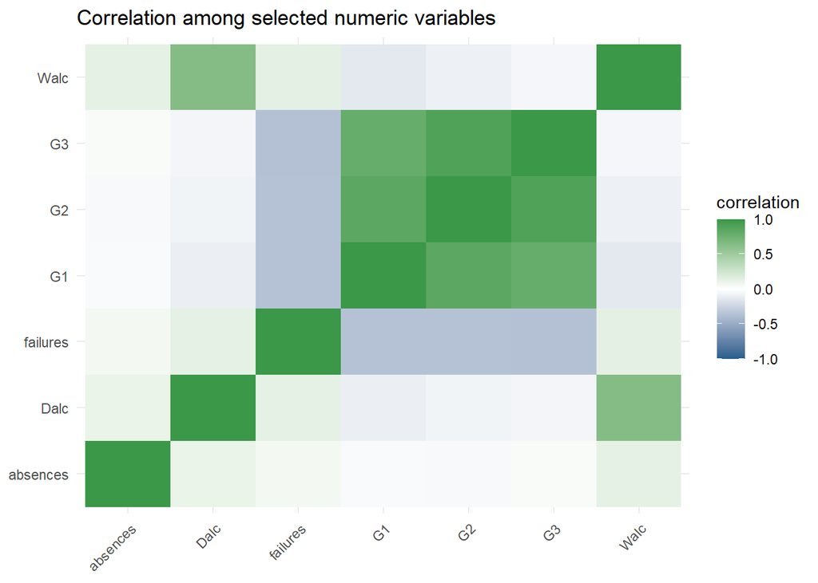

```r
# EXPECTED: a heatmap (geom_tile) of correlations among chosen numeric columns
correlation_plot(analysis_data)
```

**Modeling implication:** Consider using **G1 and G2 in predictive models**, but be careful about **multicollinearity** (might need to avoid including both if they are too correlated). **Absences and failures** could negatively influence G3.

## 3.2 Open-ended exploration

- Compare grade distributions by `failures`.

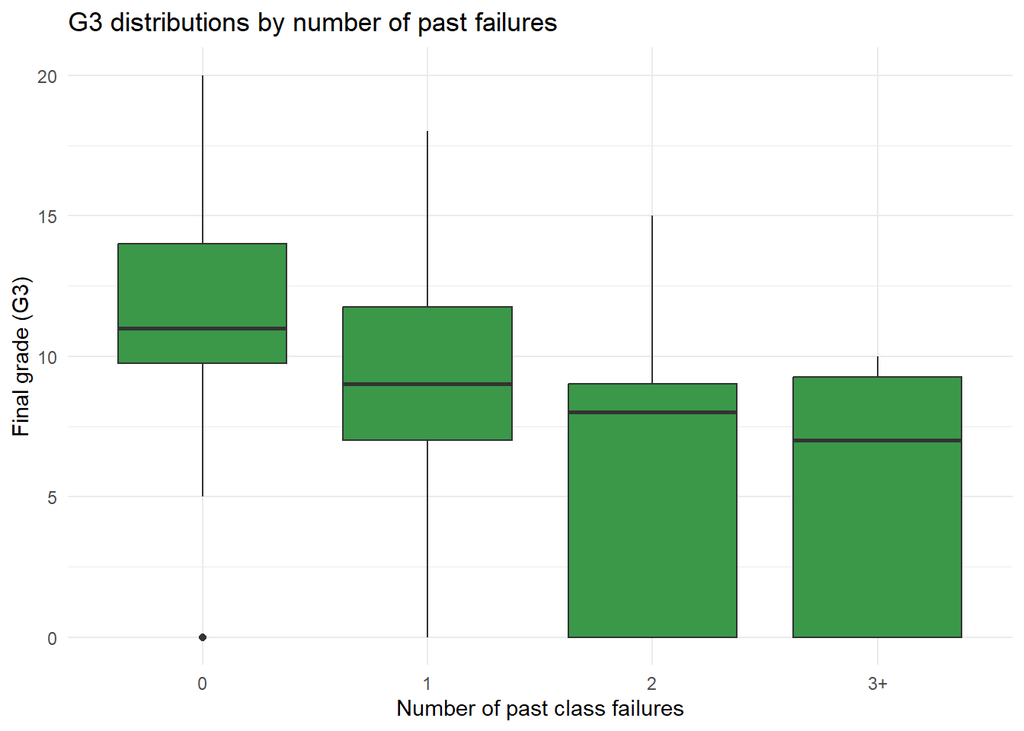

```r
compare_grades_by_failures(analysis_data)
```

**Comment:** Students who have failed **more classes in the past (2+ or 3+)** tend to have **much lower final grades**.

**Modeling implication:** Failures is a potentially strong **negative predictor**. Consider it as an ordinal or binary feature (e.g., ≥1 failure).

- Visualize `absences` vs. `G3` (scatter with smoothing).

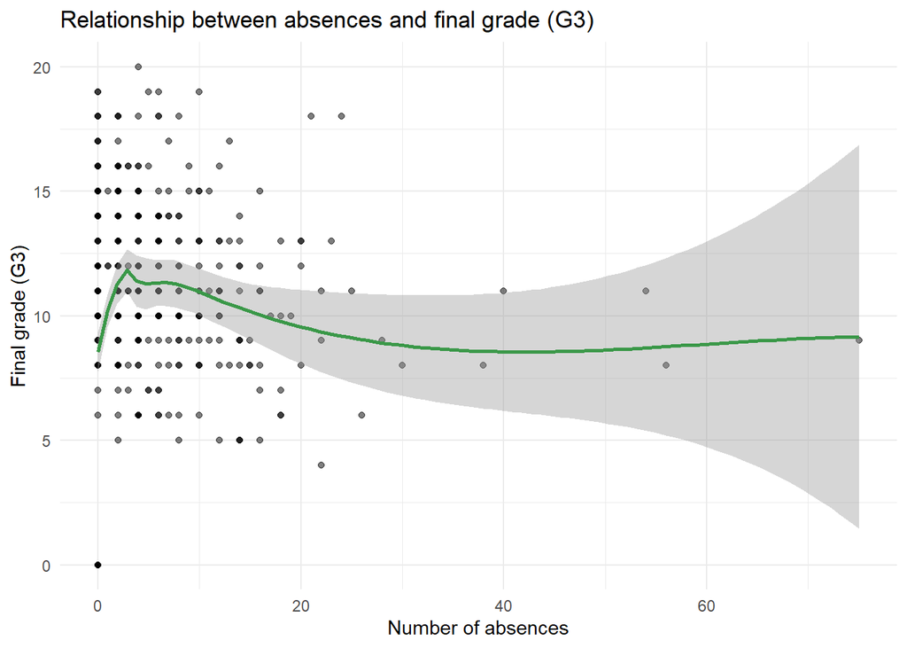

```r
plot_absences_vs_G3(analysis_data)
```

**Comment:** Students with **few absences** achieve higher grades, but after 10–15 absences, the decline stabilizes.

**Modeling implication:** The relationship is **non-linear**. Consider using **a transformation or splines** rather than treating absences as strictly linear in a regression model.

- Tabulate `Dalc`/`Walc` vs. `G3` quartiles.

```r
tabulate_alcohol_vs_G3_quartiles(analysis_data)
```

```
# A tibble: 38 × 5
   alcohol_type G3_quartile consumption     n   prop
   <chr>              <int> <ord>       <int>  <dbl>
 1 Dalc                   1 very low       65 0.657
 2 Dalc                   1 low            26 0.263
 3 Dalc                   1 medium          4 0.0404
 4 Dalc                   1 high            2 0.0202
 5 Dalc                   1 very high       2 0.0202
 6 Dalc                   2 very low       62 0.626
 7 Dalc                   2 low            19 0.192
 8 Dalc                   2 medium         12 0.121
 9 Dalc                   2 high            3 0.0303
10 Dalc                   2 very high       3 0.0303
# ℹ 28 more rows
```

**Comment:** Most students fall into **low or very low alcohol consumption**, and excessive consumption is rare but slightly associated with lower grades.

**Modeling implication:** Weak predictive power. Alcohol consumption may be **excluded** or treated as a **potential weak categorical predictor**.

- Explore `Medu`/`Fedu` vs. `G3`.

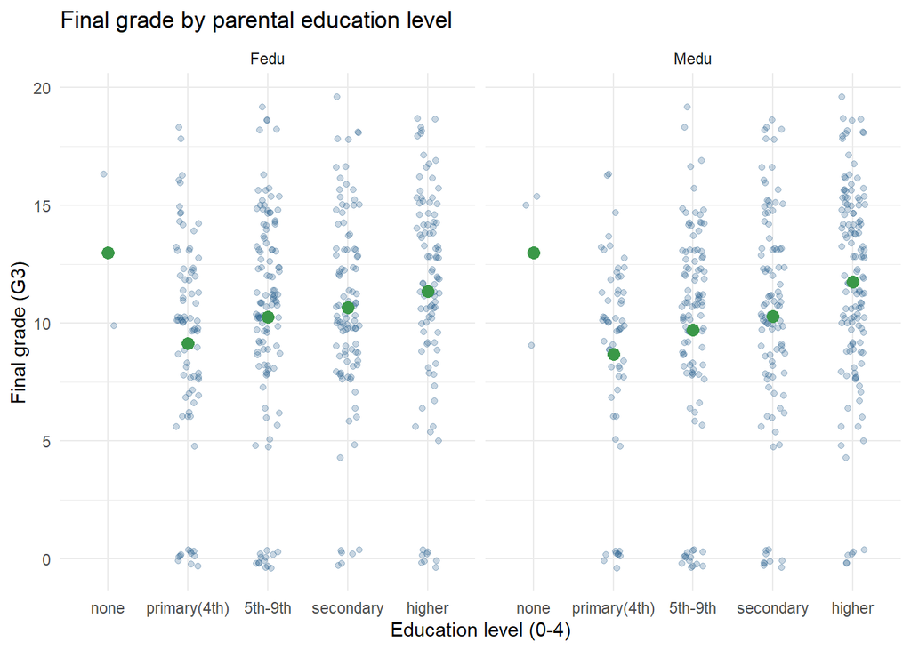

```r
plot_parent_edu_vs_G3(analysis_data)
```

**Comment:** Higher **parental education (both mother and father)** tends to associate with **slightly higher student grades**, but the effect is **not very strong**.

**Modeling implication:** Parental education can be included but will likely be **a minor predictor**. Possibly treat as ordinal.